# R Notebook

Call Libraries

```r
library(tidyverse)
library(janitor)
library(here)
library(lubridate)
```

**Labour_Productivity-OECD_Countries**

Read data

```r
gdp_phw <- read_csv(here("raw_data/OECD_GDP_per_Hour_Worked_JHios.csv")) %>%
  clean_names()
glimpse(gdp_phw)
```

```
Rows: 3,814
Columns: 8
$ location   <chr> "AUS", "AUS", "AUS", "AUS", "AUS", "AUS", "AUS", "AUS", "AUS", "AUS", "AUS", "AUS", "AUS", "AUS", "AUS", "AUS", "AUS", "AUS", "AUS"~
$ indicator  <chr> "GDPHRWKD", "GDPHRWKD", "GDPHRWKD", "GDPHRWKD", "GDPHRWKD", "GDPHRWKD", "GDPHRWKD", "GDPHRWKD", "GDPHRWKD", "GDPHRWKD", "GDPHRWKD",~
$ subject    <chr> "TOT", "TOT", "TOT", "TOT", "TOT", "TOT", "TOT", "TOT", "TOT", "TOT", "TOT", "TOT", "TOT", "TOT", "TOT", "TOT", "TOT", "TOT", "TOT"~
$ measure    <chr> "USD", "USD", "USD", "USD", "USD", "USD", "USD", "USD", "USD", "USD", "USD", "USD", "USD", "USD", "USD", "USD", "USD", "USD", "USD"~
$ frequency  <chr> "A", "A", "A", "A", "A", "A", "A", "A", "A", "A", "A", "A", "A", "A", "A", "A", "A", "A", "A", "A", "A", "A", "A", "A", "A", "A", "~
$ time       <dbl> 1970, 1971, 1972, 1973, 1974, 1975, 1976, 1977, 1978, 1979, 1980, 1981, 1982, 1983, 1984, 1985, 1986, 1987, 1988, 1989, 1990, 1991,~
$ value      <dbl> 26.84966, 27.51984, 28.12699, 28.70706, 28.24612, 29.29258, 29.78026, 29.74578, 31.00299, 31.16227, 31.51076, 32.41978, 32.80942, 3~
$ flag_codes <chr> NA, NA, NA, NA, NA, NA, NA, NA, NA, NA, NA, NA, NA, NA, NA, NA, NA, NA, NA, NA, NA, NA, NA, NA, NA, NA, NA, NA, NA, NA, NA, NA, NA,~
```

Change time in datetime format

```r
gdp_phw <- gdp_phw %>%
  mutate(time = make_datetime(time))
```

Check for NA values

```r
gdp_phw %>%
  summarise(across(.cols = everything(),
                   .fns = ~sum(is.na(.x))))
```

| location | indicator | subject | measure | frequency | time | value | flag_codes |
| --- | --- | --- | --- | --- | --- | --- | --- |
| 0 | 0 | 0 | 0 | 0 | 0 | 0 | 3760 |

```r
gdp_phw %>%
  distinct(location)
```

| location |
| --- |
| AUS |
| AUT |
| BEL |
| CAN |
| CZE |
| DNK |
| FIN |
| FRA |
| DEU |
| GRC |

[output cut: 38 more lines]

```r
  # distinct(INDICATOR) # GFCFASSET
  # distinct(subject) # OTHMACHINEQT, CULTASSET, OTHBUILDING, FIXASSET, TRANSPEQT, DWELLING
  # distinct(MEASURE) # PC_GFCF
  # distinct(FREQUENCY) #A
  # distinct(`Flag Codes`) # NA, E, B
```

View data

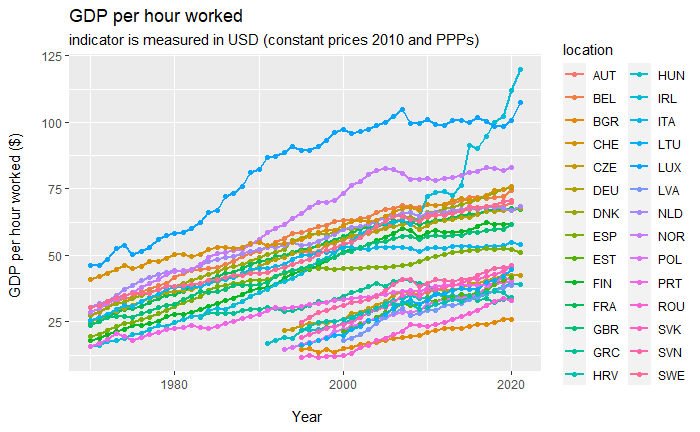

```r
gdp_phw %>%
  select(-c(indicator, subject, frequency, flag_codes)) %>%
  filter(
    location %in% c("AUT", "BEL", "BGR", "HRV", "CZE", "DNK", "EST", "FIN", "FRA",
                 "DEU", "GRC", "HUN", "IRL", "ITA", "LVA", "LTU", "LUX", "NLD",
                 "NOR", "POL", "PRT", "ROU", "SVK", "SVN", "ESP", "SWE", "CHE",
                 "GBR"),
    measure == "USD") %>%
  ggplot() +
  aes(x = time, y = value, colour = location) +
  geom_line(size = 0.75) +
  geom_point(size = 1.5) +
  # scale_colour_brewer(palette = "Dark2") +
  ggtitle(
    "GDP per hour worked",
    subtitle =  "indicator is measured in USD (constant prices 2010 and PPPs)"
  ) +
  labs(
    x = "\n Year",
    y = "GDP per hour worked ($) \n"
  )
```

```r
NA
```

GDP per hour worked data

```r
gdp_phw_europe <- gdp_phw %>%
  filter(
    location %in% c("AUT", "BEL", "BGR", "HRV", "CZE", "DNK", "EST", "FIN", "FRA",
                 "DEU", "GRC", "HUN", "IRL", "ITA", "LVA", "LTU", "LUX", "NLD",
                 "NOR", "POL", "PRT", "ROU", "SVK", "SVN", "ESP", "SWE", "CHE",
                 "GBR"),
    measure == "USD"
  ) %>%
  select(-c(indicator, frequency, measure, subject, flag_codes)) %>%
  rename(gdp_phw_usd = value)
```

OECD Investment by Asset

Read data

```r
inv_asset <- read_csv(here("raw_data/OECD_Investment_by_Asset_JHios.csv")) %>%
  clean_names()
glimpse(inv_asset)
```

```
Rows: 8,113
Columns: 8
$ location   <chr> "NZL", "NZL", "NZL", "NZL", "NZL", "NZL", "NZL", "NZL", "NZL", "NZL", "NZL", "NZL", "NZL", "NZL", "NZL", "NZL", "NZL", "NZL", "NZL"~
$ indicator  <chr> "GFCFASSET", "GFCFASSET", "GFCFASSET", "GFCFASSET", "GFCFASSET", "GFCFASSET", "GFCFASSET", "GFCFASSET", "GFCFASSET", "GFCFASSET", "~
$ subject    <chr> "OTHMACHINEQT", "OTHMACHINEQT", "OTHMACHINEQT", "OTHMACHINEQT", "OTHMACHINEQT", "OTHMACHINEQT", "OTHMACHINEQT", "OTHMACHINEQT", "OT~
$ measure    <chr> "PC_GFCF", "PC_GFCF", "PC_GFCF", "PC_GFCF", "PC_GFCF", "PC_GFCF", "PC_GFCF", "PC_GFCF", "PC_GFCF", "PC_GFCF", "PC_GFCF", "PC_GFCF",~
$ frequency  <chr> "A", "A", "A", "A", "A", "A", "A", "A", "A", "A", "A", "A", "A", "A", "A", "A", "A", "A", "A", "A", "A", "A", "A", "A", "A", "A", "~
$ time       <dbl> 1971, 1972, 1973, 1974, 1975, 1976, 1977, 1978, 1979, 1980, 1981, 1982, 1983, 1984, 1985, 1986, 1987, 1988, 1989, 1990, 1991, 1992,~
$ value      <dbl> 2.3447402, 2.3421589, 2.2280472, 2.6297086, 2.7333527, 3.1940378, 4.0083835, 4.3093129, 5.0158156, 5.4235339, 6.1697723, 7.7076256,~
$ flag_codes <chr> NA, NA, NA, NA, NA, NA, NA, NA, NA, NA, NA, NA, NA, NA, NA, NA, NA, NA, NA, NA, NA, NA, NA, NA, NA, NA, NA, NA, NA, NA, NA, NA, NA,~
```

Change time in datetime format

```r
inv_asset  <- inv_asset  %>%
  mutate(time = make_datetime(time))
```

Check for NA’s

```r
inv_asset %>%
  summarise(across(.cols = everything(),
                   .fns = ~sum(is.na(.x))))
```

| location | indicator | subject | measure | frequency | time | value | flag_codes |
| --- | --- | --- | --- | --- | --- | --- | --- |
| 0 | 0 | 0 | 0 | 0 | 0 | 0 | 7307 |

```r
inv_asset %>%
  distinct(location)
```

| location |
| --- |
| NZL |
| MEX |
| ZAF |
| FIN |
| CHE |
| GBR |
| NLD |
| FRA |
| GRC |
| SWE |

[output cut: 32 more lines]

```r
  # distinct(INDICATOR) # GFCFASSET
  # distinct(subject) # OTHMACHINEQT, CULTASSET, OTHBUILDING, FIXASSET, TRANSPEQT, DWELLING
  # distinct(MEASURE) # PC_GFCF
  # distinct(FREQUENCY) #A
  # distinct(`Flag Codes`) # NA, E, B
```

OTHMACHINEQT: Information and Communication Technology (ICT) equipment (computer software and databases, telecommunications equipment and computer hardware)

CULTASSET: cultivated biological resources (managed forests, livestock raised for milk production, etc.)

OTHBUILDING: other buildings and structures (roads, bridges, airfields, dams, etc.)

FIXASSET: intellectual property products (such as R&D, mineral exploration, software and databases, and literary and artistic originals, etc.)

TRANSPEQT: transport equipment (ships, trains, aircraft, etc.)

DWELLING: dwellings (excluding land)

Cross country investment by Asset (% GFCF)

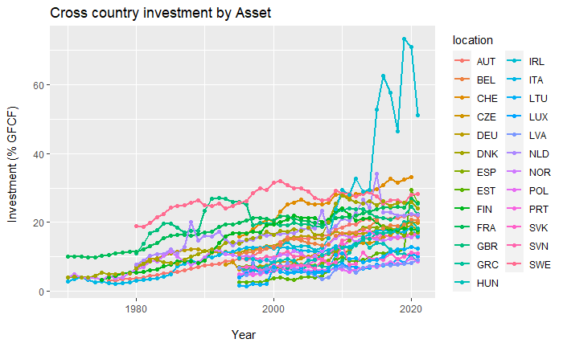

```r
inv_asset %>%
  select(-c(indicator, frequency, flag_codes)) %>%
  filter(
    location %in% c("AUT", "BEL", "BGR", "HRV", "CZE", "DNK", "EST", "FIN", "FRA",
                 "DEU", "GRC", "HUN", "IRL", "ITA", "LVA", "LTU", "LUX", "NLD",
                 "NOR", "POL", "PRT", "ROU", "SVK", "SVN", "ESP", "SWE", "CHE",
                 "GBR"),
    # subject== "OTHMACHINEQT",
    # subject == "CULTASSET",
    # subject == "OTHBUILDING",
    subject == "FIXASSET",
    # subject == "TRANSPEQT",
    # subject == "DWELLING"
  ) %>%
  ggplot() +
  aes(x = time, y = value, colour = location) +
  geom_line(size = 0.75) +
  geom_point(size = 1.5) +
  # scale_colour_brewer(palette = "Dark2") +
  ggtitle("Cross country investment by Asset") +
  labs(
    x = "\n Year",
    y = "Investment (% GFCF) \n"
  )
```

investment by Asset (% GFCF)

```r
inv_asset_europe <- inv_asset %>%
  filter(
    location %in% c("AUT", "BEL", "BGR", "HRV", "CZE", "DNK", "EST", "FIN", "FRA",
                 "DEU", "GRC", "HUN", "IRL", "ITA", "LVA", "LTU", "LUX", "NLD",
                 "NOR", "POL", "PRT", "ROU", "SVK", "SVN", "ESP", "SWE", "CHE",
                 "GBR"),
    ) %>%
  select(-c(indicator, frequency, measure, flag_codes)) %>%
  pivot_wider(names_from = subject, values_from = value) %>%
  rename(
    ict_pc_gfcf = OTHMACHINEQT,
    cultasset_pc_gfcf = CULTASSET,
    infrastuct_pc_gfcf = OTHBUILDING,
    intelprop_pc_gfcf = FIXASSET,
    transpeqt_pc_gfcf = TRANSPEQT,
    dwelling_pc_gfcf = DWELLING
  ) %>%
  arrange(location, time)
```

OECD Investment GFCF

Read data

```r
gfcf <- read_csv(here("raw_data/OECD_Investment_GFCF_JHios.csv")) %>%
  clean_names()
glimpse(gfcf)
```

```
Rows: 23,956
Columns: 8
$ location   <chr> "AUS", "AUS", "AUS", "AUS", "AUS", "AUS", "AUS", "AUS", "AUS", "AUS", "AUS", "AUS", "AUS", "AUS", "AUS", "AUS", "AUS", "AUS", "AUS"~
$ indicator  <chr> "GFCF", "GFCF", "GFCF", "GFCF", "GFCF", "GFCF", "GFCF", "GFCF", "GFCF", "GFCF", "GFCF", "GFCF", "GFCF", "GFCF", "GFCF", "GFCF", "GF~
$ subject    <chr> "TOT", "TOT", "TOT", "TOT", "TOT", "TOT", "TOT", "TOT", "TOT", "TOT", "TOT", "TOT", "TOT", "TOT", "TOT", "TOT", "TOT", "TOT", "TOT"~
$ measure    <chr> "AGRWTH", "AGRWTH", "AGRWTH", "AGRWTH", "AGRWTH", "AGRWTH", "AGRWTH", "AGRWTH", "AGRWTH", "AGRWTH", "AGRWTH", "AGRWTH", "AGRWTH", "~
$ frequency  <chr> "A", "A", "A", "A", "A", "A", "A", "A", "A", "A", "A", "A", "A", "A", "A", "A", "A", "A", "A", "A", "A", "A", "A", "A", "A", "A", "~
$ time       <chr> "1960", "1961", "1962", "1963", "1964", "1965", "1966", "1967", "1968", "1969", "1970", "1971", "1972", "1973", "1974", "1975", "19~
$ value      <dbl> 5.671711, 1.778081, 6.252030, 9.366150, 7.483513, 8.132420, 5.097216, 7.374136, 6.391864, 3.280286, 3.221345, 2.806477, 3.058763, 4~
$ flag_codes <chr> NA, NA, NA, NA, NA, NA, NA, NA, NA, NA, NA, NA, NA, NA, NA, NA, NA, NA, NA, NA, NA, NA, NA, NA, NA, NA, NA, NA, NA, NA, NA, NA, NA,~
```

Change time in datetime format

```r
gfcf <- gfcf %>%
  mutate(time = make_datetime(time))
```

Check for NA’s

```r
gfcf %>%
  summarise(across(.cols = everything(),
                   .fns = ~sum(is.na(.x))))
```

| location | indicator | subject | measure | frequency | time | value | flag_codes |
| --- | --- | --- | --- | --- | --- | --- | --- |
| 0 | 0 | 0 | 0 | 0 | 18811 | 0 | 16402 |

The timestamps missing relate to the Annual growth index (AGRWTH) - not affecting the scope of this analysis

```r
gfcf %>%
  distinct(location)
```

| location |
| --- |
| AUS |
| AUT |
| BEL |
| CAN |
| CZE |
| DNK |
| FIN |
| FRA |
| DEU |
| GRC |

[output cut: 58 more lines]

```r
  # distinct(INDICATOR) # GFCF
  # distinct(SUBJECT) # TOT
  # distinct(measure) # AGRWTH, MLN_USD, QGRWTH
  # distinct(FREQUENCY) #A, Q
  # distinct(`Flag Codes`) # NA, E, P, B, D
```

AGRWTH: Annual growth (%) MLN_USD: Million US Dollars QGRWTH: Quarterly growth rate (%)

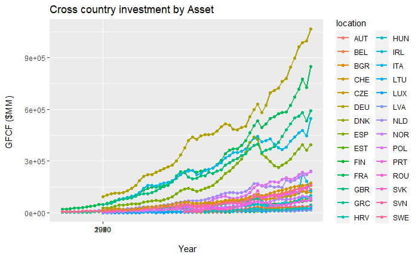

```r
gfcf %>%
  select(-c(indicator, frequency, subject, flag_codes)) %>%
  filter(
    location %in% c("AUT", "BEL", "BGR", "HRV", "CZE", "DNK", "EST", "FIN", "FRA",
                 "DEU", "GRC", "HUN", "IRL", "ITA", "LVA", "LTU", "LUX", "NLD",
                 "NOR", "POL", "PRT", "ROU", "SVK", "SVN", "ESP", "SWE", "CHE",
                 "GBR"),
    measure == "MLN_USD"
    ) %>%
  ggplot() +
  aes(x = time, y = value, color = location) +
  geom_line(size = 0.75) +
  geom_point(size = 1.5) +
  # scale_colour_brewer(palette = "Dark2") +
  ggtitle("Cross country investment by Asset") +
  labs(
    x = "\n Year",
    y = "GFCF ($MM) \n"
  ) +
  scale_x_continuous(breaks = seq(from = 1960, to = 2020, by = 10))
```

GFCF data (mln USD)

```r
gfcf_europe <- gfcf %>%
  filter(
    location %in% c("AUT", "BEL", "BGR", "HRV", "CZE", "DNK", "EST", "FIN", "FRA",
                 "DEU", "GRC", "HUN", "IRL", "ITA", "LVA", "LTU", "LUX", "NLD",
                 "NOR", "POL", "PRT", "ROU", "SVK", "SVN", "ESP", "SWE", "CHE",
                 "GBR"),
    measure == "MLN_USD"
  ) %>%
  select(location, time, value) %>%
  rename(gfcf_mln_usd = value)
```

OECD Education Spending Expenditure

Read data

```r
edu_exp <- read_csv(here("raw_data/OECD_Public_Spending_on_Education_JHios.csv")) %>%
  clean_names()
glimpse(edu_exp)
```

```
Rows: 1,620
Columns: 8
$ location   <chr> "AUS", "AUS", "AUS", "AUS", "AUS", "AUS", "AUS", "AUS", "AUS", "AUS", "AUS", "AUS", "AUS", "AUT", "AUT", "AUT", "AUT", "AUT", "AUT"~
$ indicator  <chr> "EDUPUBEXP", "EDUPUBEXP", "EDUPUBEXP", "EDUPUBEXP", "EDUPUBEXP", "EDUPUBEXP", "EDUPUBEXP", "EDUPUBEXP", "EDUPUBEXP", "EDUPUBEXP", "~
$ subject    <chr> "TRY", "TRY", "TRY", "TRY", "TRY", "TRY", "TRY", "TRY", "TRY", "TRY", "TRY", "TRY", "TRY", "TRY", "TRY", "TRY", "TRY", "TRY", "TRY"~
$ measure    <chr> "PC_GDP", "PC_GDP", "PC_GDP", "PC_GDP", "PC_GDP", "PC_GDP", "PC_GDP", "PC_GDP", "PC_GDP", "PC_GDP", "PC_GDP", "PC_GDP", "PC_GDP", "~
$ frequency  <chr> "A", "A", "A", "A", "A", "A", "A", "A", "A", "A", "A", "A", "A", "A", "A", "A", "A", "A", "A", "A", "A", "A", "A", "A", "A", "A", "~
$ time       <dbl> 2000, 2005, 2008, 2009, 2010, 2011, 2012, 2013, 2014, 2015, 2016, 2017, 2018, 2012, 2013, 2014, 2015, 2016, 2017, 2018, 2005, 2008,~
$ value      <dbl> 0.7460824, 0.6911921, 0.6902357, 0.7358844, 0.7797844, 0.7440488, 0.7194145, 0.7188712, 0.7170264, 0.7682429, 0.7551060, 0.7273703,~
$ flag_codes <lgl> NA, NA, NA, NA, NA, NA, NA, NA, NA, NA, NA, NA, NA, NA, NA, NA, NA, NA, NA, NA, NA, NA, NA, NA, NA, NA, NA, NA, NA, NA, NA, NA, NA,~
```

Change time in datetime format

```r
edu_exp <- edu_exp %>%
  mutate(time = make_datetime(time))
```

Check for NA’s

```r
edu_exp %>%
  summarise(across(.cols = everything(),
                   .fns = ~sum(is.na(.x))))
```

| location | indicator | subject | measure | frequency | time | value | flag_codes |
| --- | --- | --- | --- | --- | --- | --- | --- |
| 0 | 0 | 0 | 0 | 0 | 0 | 0 | 1620 |

```r
edu_exp %>%
  distinct(location)
```

| location |
| --- |
| AUS |
| AUT |
| BEL |
| CAN |
| CZE |
| DNK |
| FIN |
| FRA |
| DEU |
| HUN |

[output cut: 36 more lines]

```r
  # distinct(INDICATOR) #
  # distinct(SUBJECT) #
  # distinct(measure) #
  # distinct(FREQUENCY) #
  # distinct(`Flag Codes`) #
```

UK education expenditure (% GDP) TRY : TeRtiarY PRY_NTRY: PRimarY to post-secondary Non-TeRtiarY PRY_TRY: PRimarY to TeRtiarY

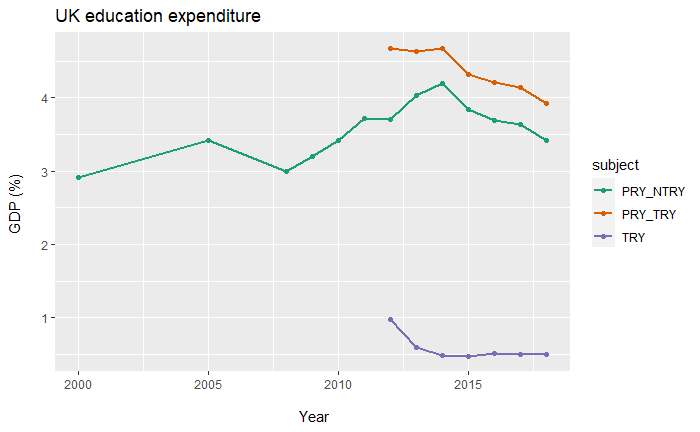

```r
edu_exp %>%
  select(-c(indicator, frequency, measure, flag_codes)) %>%
  filter(location %in% c("GBR")) %>%
  ggplot() +
  aes(x = time, y = value, colour = subject) +
  geom_line(size = 0.75) +
  geom_point(size = 1.5) +
  scale_colour_brewer(palette = "Dark2") +
  # scale_colour_manual(values = cbb_palette) +
  ggtitle("UK education expenditure") +
  labs(
    x = "\n Year",
    y = "GDP (%) \n"
  )
```

expenditure on education (% GDP)

```r
edu_exp_europe <- edu_exp %>%
  filter(
    location %in% c("AUT", "BEL", "BGR", "HRV", "CZE", "DNK", "EST", "FIN", "FRA",
                 "DEU", "GRC", "HUN", "IRL", "ITA", "LVA", "LTU", "LUX", "NLD",
                 "NOR", "POL", "PRT", "ROU", "SVK", "SVN", "ESP", "SWE", "CHE",
                 "GBR")
    ) %>%
  select(-c(indicator, frequency, measure, flag_codes)) %>%
  pivot_wider(names_from = subject, values_from = value) %>%
  rename(
    try_pc_gdp = TRY,
    pry_ntry_pc_gdp = PRY_NTRY,
    pry_try_pc_gdp = PRY_TRY
  ) %>%
  arrange(location, time)
```

**GDP-derived expenditure in USD**

OECD_Gross_Domestic_Product_GDP

Read data

```r
gdp <- read_csv(here("raw_data/OECD_Gross_Domestic_Product_GDP_JHios.csv")) %>%
  clean_names()
glimpse(gdp)
```

```
Rows: 5,137
Columns: 8
$ location   <chr> "AUS", "AUS", "AUS", "AUS", "AUS", "AUS", "AUS", "AUS", "AUS", "AUS", "AUS", "AUS", "AUS", "AUS", "AUS", "AUS", "AUS", "AUS", "AUS"~
$ indicator  <chr> "GDP", "GDP", "GDP", "GDP", "GDP", "GDP", "GDP", "GDP", "GDP", "GDP", "GDP", "GDP", "GDP", "GDP", "GDP", "GDP", "GDP", "GDP", "GDP"~
$ subject    <chr> "TOT", "TOT", "TOT", "TOT", "TOT", "TOT", "TOT", "TOT", "TOT", "TOT", "TOT", "TOT", "TOT", "TOT", "TOT", "TOT", "TOT", "TOT", "TOT"~
$ measure    <chr> "MLN_USD", "MLN_USD", "MLN_USD", "MLN_USD", "MLN_USD", "MLN_USD", "MLN_USD", "MLN_USD", "MLN_USD", "MLN_USD", "MLN_USD", "MLN_USD",~
$ frequency  <chr> "A", "A", "A", "A", "A", "A", "A", "A", "A", "A", "A", "A", "A", "A", "A", "A", "A", "A", "A", "A", "A", "A", "A", "A", "A", "A", "~
$ time       <dbl> 1960, 1961, 1962, 1963, 1964, 1965, 1966, 1967, 1968, 1969, 1970, 1971, 1972, 1973, 1974, 1975, 1976, 1977, 1978, 1979, 1980, 1981,~
$ value      <dbl> 25073.26, 25364.88, 27955.36, 30432.98, 32745.29, 34542.34, 38344.55, 41068.68, 46560.93, 52215.40, 58858.35, 64135.62, 69807.50, 7~
$ flag_codes <chr> NA, NA, NA, NA, NA, NA, NA, NA, NA, NA, NA, NA, NA, NA, NA, NA, NA, NA, NA, NA, NA, NA, NA, NA, NA, NA, NA, NA, NA, NA, NA, NA, NA,~
```

Change time in datetime format

```r
gdp <- gdp %>%
  mutate(time = make_datetime(time))
```

Check for NA’s

```r
gdp %>%
  summarise(across(.cols = everything(),
                   .fns = ~sum(is.na(.x))))
```

| location | indicator | subject | measure | frequency | time | value | flag_codes |
| --- | --- | --- | --- | --- | --- | --- | --- |
| 0 | 0 | 0 | 0 | 0 | 0 | 0 | 3824 |

```r
gdp %>%
  distinct(location)
```

| location |
| --- |
| AUS |
| AUT |
| BEL |
| CAN |
| CZE |
| DNK |
| FIN |
| FRA |
| DEU |
| GRC |

[output cut: 57 more lines]

```r
  # distinct(indicator) # GDP
  # distinct(SUBJECT) # TOT
  # distinct(MEASURE) # MLN_USD, USD_CAP
  # distinct(FREQUENCY) #A
  # distinct(`Flag Codes`) # NA, E, P, B, D
```

View data

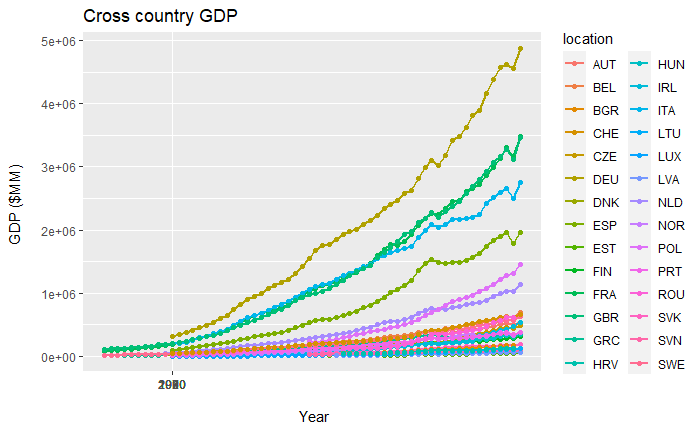

```r
gdp %>%
  select(-c(indicator, subject, frequency, flag_codes)) %>%
  filter(
    location %in% c("AUT", "BEL", "BGR", "HRV", "CZE", "DNK", "EST", "FIN", "FRA",
                 "DEU", "GRC", "HUN", "IRL", "ITA", "LVA", "LTU", "LUX", "NLD",
                 "NOR", "POL", "PRT", "ROU", "SVK", "SVN", "ESP", "SWE", "CHE",
                 "GBR"),
    measure == "MLN_USD"
    ) %>%
  ggplot() +
  aes(x = time, y = value, group = location, color = location) +
  geom_line(size = 0.75) +
  geom_point(size = 1.5) +
  # scale_colour_brewer(palette = "Dark2") +
  ggtitle("Cross country GDP") +
  labs(
    x = "\n Year",
    y = "GDP ($MM) \n"
  ) +
  scale_x_continuous(breaks = seq(from = 1960, to = 2020, by = 10))
```

GDP data (mln USD)

```r
gdp_europe <- gdp %>%
  filter(
    location %in% c("AUT", "BEL", "BGR", "HRV", "CZE", "DNK", "EST", "FIN", "FRA",
                 "DEU", "GRC", "HUN", "IRL", "ITA", "LVA", "LTU", "LUX", "NLD",
                 "NOR", "POL", "PRT", "ROU", "SVK", "SVN", "ESP", "SWE", "CHE",
                 "GBR"),
    measure == "MLN_USD"
  ) %>%
  select(location, time, value) %>%
  rename(gdp_mln_usd = value)
```

**OECD Hrs worked**

OECD_Hours_Worked

Read data

```r
hrswrkd <- read_csv(here("raw_data/OECD_Hours_Worked_JHios.csv")) %>%
  clean_names()
glimpse(hrswrkd)
```

```
Rows: 1,752
Columns: 8
$ location   <chr> "AUS", "AUS", "AUS", "AUS", "AUS", "AUS", "AUS", "AUS", "AUS", "AUS", "AUS", "AUS", "AUS", "AUS", "AUS", "AUS", "AUS", "AUS", "AUS"~
$ indicator  <chr> "HRWKD", "HRWKD", "HRWKD", "HRWKD", "HRWKD", "HRWKD", "HRWKD", "HRWKD", "HRWKD", "HRWKD", "HRWKD", "HRWKD", "HRWKD", "HRWKD", "HRWK~
$ subject    <chr> "TOT", "TOT", "TOT", "TOT", "TOT", "TOT", "TOT", "TOT", "TOT", "TOT", "TOT", "TOT", "TOT", "TOT", "TOT", "TOT", "TOT", "TOT", "TOT"~
$ measure    <chr> "HR_WKD", "HR_WKD", "HR_WKD", "HR_WKD", "HR_WKD", "HR_WKD", "HR_WKD", "HR_WKD", "HR_WKD", "HR_WKD", "HR_WKD", "HR_WKD", "HR_WKD", "~
$ frequency  <chr> "A", "A", "A", "A", "A", "A", "A", "A", "A", "A", "A", "A", "A", "A", "A", "A", "A", "A", "A", "A", "A", "A", "A", "A", "A", "A", "~
$ time       <dbl> 1985, 1986, 1987, 1988, 1989, 1990, 1991, 1992, 1993, 1994, 1995, 1996, 1997, 1998, 1999, 2000, 2001, 2002, 2003, 2004, 2005, 2006,~
$ value      <dbl> 1876, 1877, 1889, 1885, 1875, 1853, 1854, 1846, 1856, 1874, 1870, 1862, 1861, 1850, 1856, 1852, 1829, 1818, 1807, 1811, 1808, 1802,~
$ flag_codes <lgl> NA, NA, NA, NA, NA, NA, NA, NA, NA, NA, NA, NA, NA, NA, NA, NA, NA, NA, NA, NA, NA, NA, NA, NA, NA, NA, NA, NA, NA, NA, NA, NA, NA,~
```

Change time in datetime format

```r
hrswrkd <- hrswrkd %>%
  mutate(time = make_datetime(time))
```

Check for NA’s

```r
hrswrkd %>%
  summarise(across(.cols = everything(),
                   .fns = ~sum(is.na(.x))))
```

| location | indicator | subject | measure | frequency | time | value | flag_codes |
| --- | --- | --- | --- | --- | --- | --- | --- |
| 0 | 0 | 0 | 0 | 0 | 0 | 0 | 1752 |

```r
hrswrkd %>%
  distinct(location)
```

| location |
| --- |
| AUS |
| AUT |
| BEL |
| CAN |
| CZE |
| DNK |
| FIN |
| FRA |
| DEU |
| GRC |

[output cut: 36 more lines]

```r
  # distinct(indicator) #
  # distinct(SUBJECT) #
  # distinct(measure) # HR_WKD
  # distinct(FREQUENCY) #
  # distinct(`Flag Codes`) #
```

View data

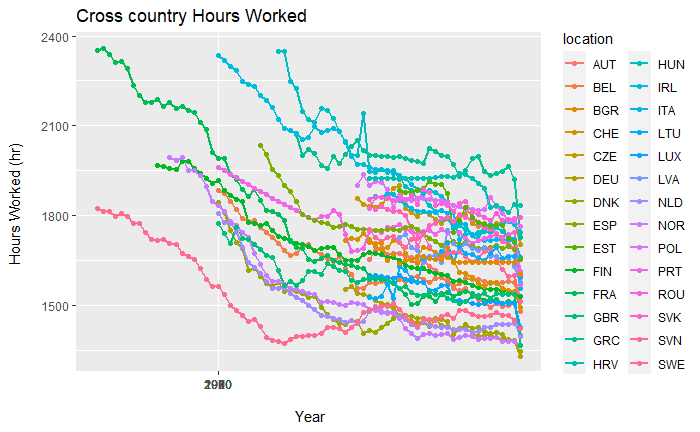

```r
hrswrkd %>%
  select(-c(indicator, subject, frequency, flag_codes)) %>%
  filter(
    location %in% c("AUT", "BEL", "BGR", "HRV", "CZE", "DNK", "EST", "FIN", "FRA",
                 "DEU", "GRC", "HUN", "IRL", "ITA", "LVA", "LTU", "LUX", "NLD",
                 "NOR", "POL", "PRT", "ROU", "SVK", "SVN", "ESP", "SWE", "CHE",
                 "GBR"),
    measure == "HR_WKD"
    ) %>%
  ggplot() +
  aes(x = time, y = value, group = location, color = location) +
  geom_line(size = 0.75) +
  geom_point(size = 1.5) +
  # scale_colour_brewer(palette = "Dark2") +
  ggtitle("Cross country Hours Worked") +
  labs(
    x = "\n Year",
    y = "Hours Worked (hr) \n"
  ) +
  scale_x_continuous(breaks = seq(from = 1960, to = 2020, by = 10))
```

Hours Worked (hrs)

```r
hrswrkd_europe <- hrswrkd %>%
  filter(
    location %in% c("AUT", "BEL", "BGR", "HRV", "CZE", "DNK", "EST", "FIN", "FRA",
                 "DEU", "GRC", "HUN", "IRL", "ITA", "LVA", "LTU", "LUX", "NLD",
                 "NOR", "POL", "PRT", "ROU", "SVK", "SVN", "ESP", "SWE", "CHE",
                 "GBR"),
    measure == "HR_WKD"
  ) %>%
  select(location, time, value) %>%
  rename(hrs_wrkd = value)
```

**OECD data for clustering**

```r
productivity_data <- gdp_phw_europe %>%
  left_join(edu_exp_europe, by = c("location", "time")) %>%
  left_join(inv_asset_europe, by = c("location", "time")) %>%
  left_join(gdp_europe, by = c("location", "time")) %>%
  left_join(gfcf_europe, by = c("location", "time")) %>%
  left_join(hrswrkd_europe, by = c("location", "time"))

glimpse(productivity_data)
```

```
Rows: 1,122
Columns: 15
$ location           <chr> "AUT", "AUT", "AUT", "AUT", "AUT", "AUT", "AUT", "AUT", "AUT", "AUT", "AUT", "AUT", "AUT", "AUT", "AUT", "AUT", "AUT", "AUT~
$ time               <dttm> 1995-01-01, 1996-01-01, 1997-01-01, 1998-01-01, 1999-01-01, 2000-01-01, 2001-01-01, 2002-01-01, 2003-01-01, 2004-01-01, 20~
$ gdp_phw_usd        <dbl> 51.10577, 51.17527, 51.62205, 53.56842, 54.51397, 55.82518, 56.53355, 57.59156, 58.07162, 59.18159, 60.63234, 62.21878, 63.~
$ try_pc_gdp         <dbl> NA, NA, NA, NA, NA, NA, NA, NA, NA, NA, NA, NA, NA, NA, NA, NA, NA, 1.661568, 1.644516, 1.614541, 1.634081, 1.631474, 1.560~
$ pry_ntry_pc_gdp    <dbl> NA, NA, NA, NA, NA, NA, NA, NA, NA, NA, NA, NA, NA, NA, NA, NA, NA, 2.993731, 3.071253, 2.979963, 2.980174, 2.988191, 2.941~
$ pry_try_pc_gdp     <dbl> NA, NA, NA, NA, NA, NA, NA, NA, NA, NA, NA, NA, NA, NA, NA, NA, NA, 4.655299, 4.715770, 4.594504, 4.614255, 4.619665, 4.502~
$ ict_pc_gfcf        <dbl> 10.88201, 10.75168, 10.82362, 12.44367, 13.88316, 13.02669, 14.07281, 14.21942, 13.45138, 13.28095, 12.67514, 12.51863, 11.~
$ intelprop_pc_gfcf  <dbl> 9.443503, 9.615562, 10.305807, 11.399541, 12.458756, 12.810765, 14.283512, 15.687502, 15.314073, 15.181637, 15.262063, 16.2~
$ transpeqt_pc_gfcf  <dbl> 9.397688, 8.845437, 8.987988, 9.437190, 9.702266, 10.419917, 9.574734, 9.941804, 9.901826, 9.851118, 10.066695, 8.970145, 9~
$ dwelling_pc_gfcf   <dbl> 25.51164, 25.20402, 24.64195, 23.43691, 22.88900, 20.56117, 19.56446, 19.55534, 18.31704, 18.62982, 18.97404, 19.04542, 18.~
$ infrastuct_pc_gfcf <dbl> 30.16149, 29.27102, 29.57054, 29.57852, 29.58367, 30.42002, 30.09122, 29.41146, 31.52808, 31.98303, 31.27218, 30.49951, 29.~
$ cultasset_pc_gfcf  <dbl> 0.3290037, 0.2676258, 0.2001148, 0.2419520, 0.2083351, 0.2394522, 0.2084752, 0.2024288, 0.1681644, 0.2151342, 0.2561053, 0.~
$ gdp_mln_usd        <dbl> 188252.03, 195424.46, 202601.15, 212781.09, 220639.94, 235347.82, 238878.52, 251984.78, 261057.08, 275998.47, 288086.72, 31~
$ gfcf_mln_usd       <dbl> 47625.99, 50403.57, 51500.02, 54195.81, 55070.06, 60276.53, 59233.80, 59293.46, 62935.94, 65112.20, 66410.09, 70382.13, 749~
$ hrs_wrkd           <dbl> 1653.0, 1683.0, 1691.0, 1671.0, 1675.0, 1675.0, 1663.0, 1661.0, 1652.0, 1655.0, 1632.0, 1617.0, 1606.0, 1599.0, 1558.0, 155~
```

```r
productivity_data %>%
  mutate(time = year(time)) %>%
  filter(time == 2018)
```

| location | time | gdp_phw_usd | try_pc_gdp | pry_ntry_pc_gdp | pry_try_pc_gdp | ict_pc_gfcf | intelprop_pc_gfcf | transpeqt_pc_gfcf | dwelling_pc_gfcf | infrastuct_pc_gfcf | cultasset_pc_gfcf | gdp_mln_usd | gfcf_mln_usd | hrs_wrkd |
| --- | --- | --- | --- | --- | --- | --- | --- | --- | --- | --- | --- | --- | --- | --- |
| AUT | 2018 | 68.36028 | 1.5519710 | 2.826723 | 4.378695 | 14.421296 | 21.300544 | 9.275621 | 18.717409 | 27.04737 | 0.133570514 | 503557.21 | 121288.94 | 1502.0 |
| BEL | 2018 | 71.70012 | 1.2681330 | 3.972353 | 5.240486 | 12.302061 | 18.955793 | 9.174746 | 24.860148 | 23.25213 | 0.072505426 | 600323.29 | 141626.66 | 1580.0 |
| CZE | 2018 | 41.15272 | 0.9095964 | 2.685061 | 3.594657 | 16.431908 | 17.718675 | 10.282118 | 16.380117 | 24.44245 | 0.275680523 | 437267.33 | 115024.11 | 1785.0 |
| DNK | 2018 | 73.76959 | 1.4076230 | 3.318589 | 4.726211 | NA | 25.681604 | 12.827174 | 22.247802 | 23.88646 | -0.024046702 | 333035.35 | 72359.60 | 1381.0 |
| FIN | 2018 | 61.54729 | 1.3962310 | 3.580011 | 4.976242 | 9.193172 | 17.676165 | 3.776943 | 29.966360 | 29.91830 | 0.048057242 | 273463.02 | 65807.62 | 1546.0 |
| FRA | 2018 | 67.15515 | 1.1249240 | 3.366300 | 4.491224 | 16.406327 | 24.569196 | 7.395804 | 27.736898 | 25.13368 | 0.185574366 | 3125379.86 | 715481.78 | 1514.0 |
| DEU | 2018 | 66.43817 | 1.0352350 | 2.636021 | 3.671256 | 6.824248 | 18.069960 | 9.693772 | 29.661706 | 19.05603 | 0.007755469 | 4579333.45 | 964279.38 | 1386.9 |
| GRC | 2018 | 32.41078 | 0.6620562 | 2.631294 | 3.293350 | NA | 18.284456 | 9.576445 | 6.692142 | 31.34070 | 0.354689936 | 317881.48 | 35436.63 | 1965.0 |
| HUN | 2018 | 36.72045 | 0.7234649 | 2.542985 | 3.266450 | 6.974090 | 11.102812 | 10.742419 | 12.111272 | 36.56423 | 0.470907080 | 311968.30 | 77142.43 | 1729.9 |
| IRL | 2018 | 99.80872 | 0.5951987 | 2.162463 | 2.757662 | 6.213592 | 46.517766 | 21.555299 | 8.246511 | 16.48138 | -0.019006007 | 411558.74 | 116232.12 | 1782.0 |

[output cut: 18 more lines]

Drop european countries that don’t have data for 2018

```r
productivity_data %>%
  mutate(time = year(time)) %>%
  filter(time == 2018) %>%
  drop_na()
```

| location | time | gdp_phw_usd | try_pc_gdp | pry_ntry_pc_gdp | pry_try_pc_gdp | ict_pc_gfcf | intelprop_pc_gfcf | transpeqt_pc_gfcf | dwelling_pc_gfcf | infrastuct_pc_gfcf | cultasset_pc_gfcf | gdp_mln_usd | gfcf_mln_usd | hrs_wrkd |
| --- | --- | --- | --- | --- | --- | --- | --- | --- | --- | --- | --- | --- | --- | --- |
| AUT | 2018 | 68.36028 | 1.5519710 | 2.826723 | 4.378695 | 14.421296 | 21.300544 | 9.275621 | 18.717409 | 27.04737 | 0.133570514 | 503557.21 | 121288.94 | 1502.0 |
| BEL | 2018 | 71.70012 | 1.2681330 | 3.972353 | 5.240486 | 12.302061 | 18.955793 | 9.174746 | 24.860148 | 23.25213 | 0.072505426 | 600323.29 | 141626.66 | 1580.0 |
| CZE | 2018 | 41.15272 | 0.9095964 | 2.685061 | 3.594657 | 16.431908 | 17.718675 | 10.282118 | 16.380117 | 24.44245 | 0.275680523 | 437267.33 | 115024.11 | 1785.0 |
| FIN | 2018 | 61.54729 | 1.3962310 | 3.580011 | 4.976242 | 9.193172 | 17.676165 | 3.776943 | 29.966360 | 29.91830 | 0.048057242 | 273463.02 | 65807.62 | 1546.0 |
| FRA | 2018 | 67.15515 | 1.1249240 | 3.366300 | 4.491224 | 16.406327 | 24.569196 | 7.395804 | 27.736898 | 25.13368 | 0.185574366 | 3125379.86 | 715481.78 | 1514.0 |
| DEU | 2018 | 66.43817 | 1.0352350 | 2.636021 | 3.671256 | 6.824248 | 18.069960 | 9.693772 | 29.661706 | 19.05603 | 0.007755469 | 4579333.45 | 964279.38 | 1386.9 |
| HUN | 2018 | 36.72045 | 0.7234649 | 2.542985 | 3.266450 | 6.974090 | 11.102812 | 10.742419 | 12.111272 | 36.56423 | 0.470907080 | 311968.30 | 77142.43 | 1729.9 |
| IRL | 2018 | 99.80872 | 0.5951987 | 2.162463 | 2.757662 | 6.213592 | 46.517766 | 21.555299 | 8.246511 | 16.48138 | -0.019006007 | 411558.74 | 116232.12 | 1782.0 |
| ITA | 2018 | 53.39327 | 0.5585754 | 2.927140 | 3.485715 | 12.578667 | 17.177767 | 7.193391 | 22.891901 | 21.36659 | 0.208936405 | 2600326.87 | 464057.90 | 1719.4 |
| LUX | 2018 | 98.60259 | 0.3743456 | 2.736333 | 3.110679 | 9.968185 | 9.264415 | 16.717007 | 22.741199 | 37.51188 | -0.032091194 | 71109.24 | 11567.07 | 1506.0 |

[output cut: 10 more lines]

The loss of data is not significant

```r
productivity_data <- productivity_data %>%
  mutate(time = year(time)) %>%
  filter(time == 2018) %>%
  drop_na() %>%
  mutate(
    try_phw_usd = try_pc_gdp * gdp_phw_usd / 100,
    pry_ntry_phw_usd = pry_ntry_pc_gdp * gdp_phw_usd / 100,
    pry_try_phw_usd = pry_try_pc_gdp * gdp_phw_usd / 100,
    ict_phw_usd = ict_pc_gfcf * gfcf_mln_usd / hrs_wrkd / 100,
    dwelling_phw_usd = dwelling_pc_gfcf * gfcf_mln_usd / hrs_wrkd / 100,
    infrastuct_phw_usd = infrastuct_pc_gfcf * gfcf_mln_usd / hrs_wrkd / 100,
    cultasset_phw_usd = cultasset_pc_gfcf * gfcf_mln_usd / hrs_wrkd / 100,
    transpeqt_phw_usd = transpeqt_pc_gfcf * gfcf_mln_usd / hrs_wrkd / 100,
    intelprop_phw_usd = intelprop_pc_gfcf * gfcf_mln_usd / hrs_wrkd / 100
  ) %>%
  select(
    location,
    time,
    gdp_phw_usd,
    try_phw_usd,
    pry_ntry_phw_usd,
    pry_try_phw_usd,
    ict_phw_usd,
    dwelling_phw_usd,
    infrastuct_phw_usd,
    cultasset_phw_usd,
    transpeqt_phw_usd,
    intelprop_phw_usd
  )
```

Prepare data for K-means clustering

```r
productivity_data <- productivity_data %>%
  select(-time) %>%
  column_to_rownames("location")
```

Standardise data

```r
productivity_data_scale <- productivity_data %>%
  mutate(across(where(is.numeric), scale))

productivity_data_scale
```

|  | gdp_phw_usd | try_phw_usd | pry_ntry_phw_usd | pry_try_phw_usd | ict_phw_usd | dwelling_phw_usd | infrastuct_phw_usd | cultasset_phw_usd | transpeqt_phw_usd | intelprop_phw_usd |
| --- | --- | --- | --- | --- | --- | --- | --- | --- | --- | --- |
| AUT | 0.43399575 | 1.41612607 | 0.09859846 | 0.5218008079 | -0.27403672 | -0.38758103 | -0.371984246 | -0.4395379 | -0.33009246 | -0.32200329 |
| BEL | 0.61095390 | 0.96665740 | 1.28699953 | 1.2416983858 | -0.30352235 | -0.25021368 | -0.396250277 | -0.5040785 | -0.28320389 | -0.32767075 |
| CZE | -1.00756994 | -0.61849424 | -0.97503271 | -0.9045185009 | -0.32444176 | -0.47494093 | -0.519979903 | -0.3344716 | -0.38533479 | -0.47873385 |
| FIN | 0.07301598 | 0.81875765 | 0.45031234 | 0.5872326762 | -0.64282269 | -0.43278092 | -0.593250664 | -0.5711288 | -0.70599306 | -0.58426482 |
| FRA | 0.37014324 | 0.51087797 | 0.52459411 | 0.5432806736 | 2.86842568 | 1.83433626 | 1.983418207 | 0.7184098 | 1.42468309 | 2.35870873 |
| DEU | 0.33215482 | 0.31040177 | -0.13631305 | -0.0002817346 | 1.43352607 | 3.27429750 | 2.316704195 | -0.5207446 | 3.49813532 | 2.61694284 |
| HUN | -1.24240910 | -0.94049756 | -1.19716052 | -1.1681575410 | -0.68113121 | -0.57370125 | -0.506499977 | -0.2857706 | -0.50261264 | -0.65400011 |
| IRL | 2.10025988 | 0.03264931 | 0.39182434 | 0.2948494095 | -0.63616184 | -0.57412294 | -0.641484962 | -0.6205905 | 0.08969969 | 0.03415841 |
| ITA | -0.35901625 | -0.84394727 | -0.38082281 | -0.5447911247 | 0.78973479 | 0.50662921 | 0.498550440 | 0.2470648 | 0.43189407 | 0.46836288 |
| LUX | 2.03635449 | -0.63393056 | 1.09224291 | 0.5914421345 | -0.79294530 | -0.64371697 | -0.832690726 | -0.6056375 | -0.72667997 | -0.76890579 |

[output cut: 10 more lines]

Check data if mean==0 and std==1

```r
productivity_data_scale %>%
  pivot_longer(cols = everything(),
               names_to = "type",
               values_to = "value") %>% #convert data to long format
  group_by(type) %>%
  summarise(mean = round(mean(value)),
            sd = sd(value))
```

| type | mean | sd |
| --- | --- | --- |
| cultasset_phw_usd | 0 | 1 |
| dwelling_phw_usd | 0 | 1 |
| gdp_phw_usd | 0 | 1 |
| ict_phw_usd | 0 | 1 |
| infrastuct_phw_usd | 0 | 1 |
| intelprop_phw_usd | 0 | 1 |
| pry_ntry_phw_usd | 0 | 1 |
| pry_try_phw_usd | 0 | 1 |
| transpeqt_phw_usd | 0 | 1 |
| try_phw_usd | 0 | 1 |

Clustering with K-means

```r
set.seed(340717)

clust_data_scale <- kmeans(productivity_data_scale,
                        centers = 4,
                        nstart = 25)

clust_data_scale
```

```
K-means clustering with 4 clusters of sizes 3, 7, 8, 2

Cluster means:
  gdp_phw_usd try_phw_usd pry_ntry_phw_usd pry_try_phw_usd ict_phw_usd dwelling_phw_usd infrastuct_phw_usd cultasset_phw_usd transpeqt_phw_usd
1  -0.2696117  -0.7173785       -0.2613776      -0.4178334   0.9885049        0.6198135          0.9682463         1.7541925         0.5213699
2  -1.0287139  -0.7820800       -0.9808827      -0.9607729  -0.6398138       -0.5641219         -0.5330715        -0.1712680        -0.4991226
3   0.9134418   0.8506770        0.9077538       0.9294890  -0.3485962       -0.3774026         -0.4341701        -0.5326708        -0.3741338
4   0.3511490   0.4106399        0.1941405       0.2714995   2.1509759        2.5543169          2.1500612         0.0988326         2.4614092
  intelprop_phw_usd
1         0.6926594
2        -0.6446741
3        -0.3176139
4         2.4878258

Clustering vector:
AUT BEL CZE FIN FRA DEU HUN IRL ITA LUX NLD NOR POL PRT SVK ESP SWE GBR SVN LTU
  3   3   2   3   4   4   2   3   1   3   3   3   2   2   2   1   3   1   2   2

Within cluster sum of squares by cluster:
[1] 10.092995  3.062523 23.030868  5.459395
 (between_SS / total_SS =  78.1 %)

Available components:

[1] "cluster"      "centers"      "totss"        "withinss"     "tot.withinss" "betweenss"    "size"         "iter"         "ifault"
```

```r
library(broom)

tidy(clust_data_scale,
     col.names = colnames(productivity_data_scale))
```

| gdp_phw_usd | try_phw_usd | pry_ntry_phw_usd | pry_try_phw_usd | ict_phw_usd | dwelling_phw_usd | infrastuct_phw_usd | cultasset_phw_usd | transpeqt_phw_usd | intelprop_phw_usd | size | withinss | cluster |
| --- | --- | --- | --- | --- | --- | --- | --- | --- | --- | --- | --- | --- |
| -0.2696117 | -0.7173785 | -0.2613776 | -0.4178334 | 0.9885049 | 0.6198135 | 0.9682463 | 1.7541925 | 0.5213699 | 0.6926594 | 3 | 10.092995 | 1 |
| -1.0287139 | -0.7820800 | -0.9808827 | -0.9607729 | -0.6398138 | -0.5641219 | -0.5330715 | -0.1712680 | -0.4991226 | -0.6446741 | 7 | 3.062523 | 2 |
| 0.9134418 | 0.8506770 | 0.9077538 | 0.9294890 | -0.3485962 | -0.3774026 | -0.4341701 | -0.5326708 | -0.3741338 | -0.3176139 | 8 | 23.030868 | 3 |
| 0.3511490 | 0.4106399 | 0.1941405 | 0.2714995 | 2.1509759 | 2.5543169 | 2.1500612 | 0.0988326 | 2.4614092 | 2.4878258 | 2 | 5.459395 | 4 |

```r
augment(clust_data_scale, productivity_data)
```

| .rownames | gdp_phw_usd | try_phw_usd | pry_ntry_phw_usd | pry_try_phw_usd | ict_phw_usd | dwelling_phw_usd | infrastuct_phw_usd | cultasset_phw_usd | transpeqt_phw_usd | intelprop_phw_usd | .cluster |
| --- | --- | --- | --- | --- | --- | --- | --- | --- | --- | --- | --- |
| AUT | 68.36028 | 1.0609317 | 1.9323558 | 2.993288 | 11.6454310 | 15.114612 | 21.841193 | 0.107860362 | 7.490215 | 17.2005354 | 3 |
| BEL | 71.70012 | 0.9092529 | 2.8481819 | 3.757435 | 11.0272142 | 22.283923 | 20.842542 | 0.064991781 | 8.223979 | 16.9914282 | 3 |
| CZE | 41.15272 | 0.3743236 | 1.1049756 | 1.479299 | 10.5886029 | 10.555229 | 15.750541 | 0.177646535 | 6.625722 | 11.4177861 | 2 |
| FIN | 61.54729 | 0.8593423 | 2.2033996 | 3.062742 | 3.9132003 | 12.755594 | 12.735137 | 0.020456226 | 1.607708 | 7.5241031 | 3 |
| FRA | 67.15515 | 0.7554444 | 2.2606439 | 3.016088 | 77.5325478 | 131.078240 | 118.776034 | 0.876982020 | 34.950878 | 116.1084014 | 4 |
| DEU | 66.43817 | 0.6877912 | 1.7513242 | 2.439115 | 47.4474152 | 206.230961 | 132.492172 | 0.053921974 | 67.398545 | 125.6362377 | 4 |
| HUN | 36.72045 | 0.2656596 | 0.9337956 | 1.199455 | 3.1099964 | 5.400850 | 16.305298 | 0.209994320 | 4.790429 | 4.9511414 | 2 |
| IRL | 99.80872 | 0.5940602 | 2.1583266 | 2.752387 | 4.0528564 | 5.378841 | 10.750091 | -0.012396793 | 14.059586 | 30.3415194 | 3 |
| ITA | 53.39327 | 0.2982417 | 1.5628959 | 1.861137 | 33.9492262 | 61.784154 | 57.667402 | 0.563909434 | 19.414621 | 46.3619785 | 1 |
| LUX | 98.60259 | 0.3691145 | 2.6980952 | 3.067210 | 0.7656223 | 1.746674 | 2.881159 | -0.002464815 | 1.283976 | 0.7115681 | 3 |

[output cut: 10 more lines]

Clustering Metrics

```r
glance(clust_data_scale)
```

| totss | tot.withinss | betweenss | iter |
| --- | --- | --- | --- |
| 190 | 41.64578 | 148.3542 | 2 |

```r
library(broom)

# Set min & max number of clusters want to look at
max_k <- 15

k_clusters <- tibble(k = 1:max_k) %>%
  mutate(
    kclust = map(k, ~ kmeans(productivity_data_scale, .x, nstart = 25)),
    tidied = map(kclust, tidy),
    glanced = map(kclust, glance),
    augmented = map(kclust, augment, productivity_data)
  )

k_clusters
```

| k | kclust | tidied | glanced | augmented |
| --- | --- | --- | --- | --- |
| 1 |  |  |  |  |
| 2 |  |  |  |  |
| 3 |  |  |  |  |
| 4 |  |  |  |  |
| 5 |  |  |  |  |
| 6 |  |  |  |  |
| 7 |  |  |  |  |
| 8 |  |  |  |  |
| 9 |  |  |  |  |
| 10 |  |  |  |  |

[output cut: 5 more lines]

```r
clusterings <- k_clusters %>%
  unnest(c(glanced))

clusterings
```

| k | kclust | tidied | totss | tot.withinss | betweenss | iter | augmented |
| --- | --- | --- | --- | --- | --- | --- | --- |
| 1 |  |  | 190 | 190.000000 | 5.684342e-14 | 1 |  |
| 2 |  |  | 190 | 116.034035 | 7.396596e+01 | 1 |  |
| 3 |  |  | 190 | 62.270138 | 1.277299e+02 | 1 |  |
| 4 |  |  | 190 | 41.645781 | 1.483542e+02 | 2 |  |
| 5 |  |  | 190 | 30.658680 | 1.593413e+02 | 2 |  |
| 6 |  |  | 190 | 23.450125 | 1.665499e+02 | 2 |  |
| 7 |  |  | 190 | 16.595893 | 1.734041e+02 | 2 |  |
| 8 |  |  | 190 | 11.136498 | 1.788635e+02 | 4 |  |
| 9 |  |  | 190 | 7.897736 | 1.821023e+02 | 4 |  |
| 10 |  |  | 190 | 6.167058 | 1.838329e+02 | 3 |  |

[output cut: 5 more lines]

Choosing the number of clusters

**Elbow method**

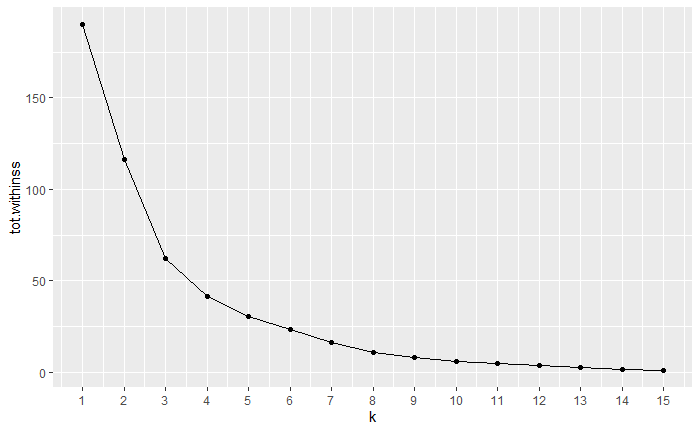

```r
ggplot(clusterings, aes(x = k, y = tot.withinss)) +
  geom_point() +
  geom_line() +
  scale_x_continuous(breaks = seq(1,20, by = 1))
```

If you want to use a function to do the plot above, use this:

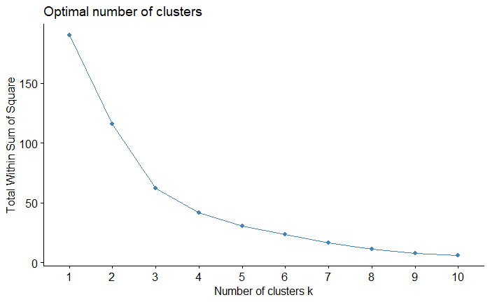

```r
library(factoextra)

fviz_nbclust(productivity_data_scale,
             kmeans,
             method = "wss",
             nstart = 25)
```

**Silhouette coefficient**

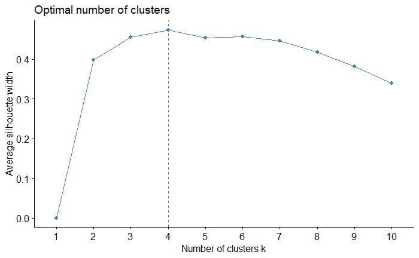

```r
fviz_nbclust(productivity_data_scale, kmeans, method = "silhouette", nstart = 25)
```

**Gap statistic**

```
Clustering k = 1,2,..., K.max (= 10): .. done
Bootstrapping, b = 1,2,..., B (= 100)  [one "." per sample]:
.................................................. 50
.................................................. 100
```

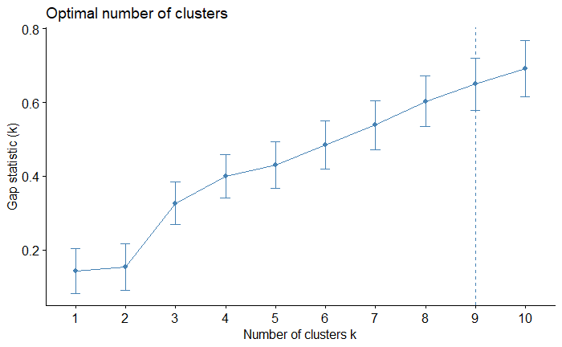

```r
fviz_nbclust(productivity_data_scale, kmeans, method = "gap_stat", nstart = 100)
```

Method #2 indicates k=4 clusters and method #3 indicates k=9 clusters.

Let’s see if k=4 is sufficient

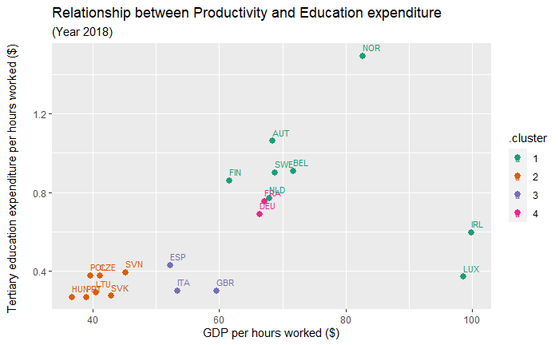

```r
clusterings %>%
  unnest(cols = c(augmented)) %>%
  filter(k == 4) %>%
  ggplot(aes(x = gdp_phw_usd, y = try_phw_usd, colour = .cluster, label = .rownames)) +
  geom_point(aes(color = .cluster), size = 2.5) +
  geom_text(hjust = 0, vjust = - 0.75, size = 3) +
  scale_colour_brewer(palette = "Dark2") +
  ggtitle(
    "Relationship between Productivity and Education expenditure",
    subtitle = "(Year 2018)"
  ) +
  labs(
    x = "GDP per hours worked ($)",
    y = "Tertiary education expenditure per hours worked ($) \n"
  )
```

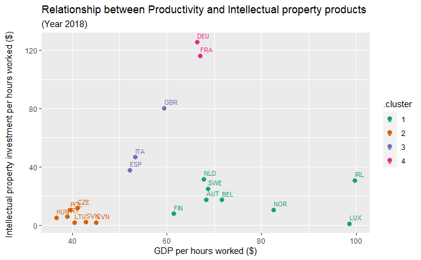

```r
clusterings %>%
  unnest(cols = c(augmented)) %>%
  filter(k == 4) %>%
  ggplot(aes(x = gdp_phw_usd, y = intelprop_phw_usd, colour = .cluster, label = .rownames)) +
  geom_point(aes(color = .cluster), size = 2.5) +
  geom_text(hjust = 0, vjust = - 0.75, size = 3) +
  scale_colour_brewer(palette = "Dark2") +
  ggtitle(
    "Relationship between Productivity and Intellectual property products",
    subtitle = "(Year 2018)"
  ) +
  labs(
    x = "GDP per hours worked ($)",
    y = "Intellectual property investment per hours worked ($) \n"
  )
```

```r
productivity_data %>%
  names()
```

```
 [1] "gdp_phw_usd"        "try_phw_usd"        "pry_ntry_phw_usd"   "pry_try_phw_usd"    "ict_phw_usd"        "dwelling_phw_usd"   "infrastuct_phw_usd"
 [8] "cultasset_phw_usd"  "transpeqt_phw_usd"  "intelprop_phw_usd"
```

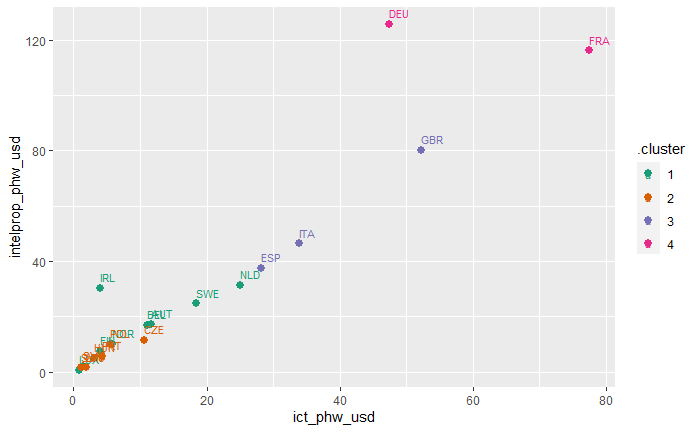

```r
clusterings %>%
  unnest(cols = c(augmented)) %>%
  filter(k == 4) %>%
  ggplot(aes(x = ict_phw_usd, y = intelprop_phw_usd, colour = .cluster, label = .rownames)) +
  geom_point(aes(color = .cluster), size = 2.5) +
  geom_text(hjust = 0, vjust = - 0.75, size = 3) +
  scale_colour_brewer(palette = "Dark2")
```

What are the average scores for each investment factor/asset split by cluster?

```r
clusterings %>%
  unnest(augmented) %>%
  filter(k == 4) %>%
  group_by(.cluster) %>%
  summarise(mean(gdp_phw_usd), mean(try_phw_usd), mean(pry_ntry_phw_usd),
            mean(pry_try_phw_usd), mean(ict_phw_usd), mean(dwelling_phw_usd),
            mean(infrastuct_phw_usd), mean(cultasset_phw_usd), mean(transpeqt_phw_usd),
            mean(intelprop_phw_usd))
```

| .cluster | mean(gdp_phw_usd) | mean(try_phw_usd) | mean(pry_ntry_phw_usd) | mean(pry_try_phw_usd) | mean(ict_phw_usd) | mean(dwelling_phw_usd) | mean(infrastuct_phw_usd) | mean(cultasset_phw_usd) | mean(transpeqt_phw_usd) | mean(intelprop_phw_usd) |
| --- | --- | --- | --- | --- | --- | --- | --- | --- | --- | --- |
| 1 | 77.40916 | 0.8701139 | 2.555921 | 3.426035 | 10.082164 | 15.645832 | 19.28198 | 0.04600044 | 6.801008 | 17.362486 |
| 2 | 40.75366 | 0.3191196 | 1.100467 | 1.419587 | 3.976286 | 5.900802 | 15.21177 | 0.28604819 | 4.845046 | 5.295236 |
| 3 | 55.08066 | 0.3409539 | 1.654945 | 1.995899 | 38.116782 | 67.691333 | 76.99739 | 1.56496032 | 20.814836 | 54.637650 |
| 4 | 66.79666 | 0.7216178 | 2.005984 | 2.727602 | 62.489982 | 168.654600 | 125.63410 | 0.46545200 | 51.174712 | 120.872320 |

**Compare how the UK does (cluster 3) against France and Germany in cluster 4**

Get row that corresponds to cluster 4

```r
cluster_4_fradeu <- clusterings %>%
  unnest(augmented) %>%
  filter(k == 4) %>%
  group_by(.cluster) %>%
  summarise(mean(gdp_phw_usd), mean(try_phw_usd), mean(pry_ntry_phw_usd),
            mean(pry_try_phw_usd), mean(ict_phw_usd), mean(dwelling_phw_usd),
            mean(infrastuct_phw_usd), mean(cultasset_phw_usd), mean(transpeqt_phw_usd),
            mean(intelprop_phw_usd)) %>%
  filter(.cluster %in% c(4))

cluster_4_fradeu
```

| .cluster | mean(gdp_phw_usd) | mean(try_phw_usd) | mean(pry_ntry_phw_usd) | mean(pry_try_phw_usd) | mean(ict_phw_usd) | mean(dwelling_phw_usd) | mean(infrastuct_phw_usd) | mean(cultasset_phw_usd) | mean(transpeqt_phw_usd) | mean(intelprop_phw_usd) |
| --- | --- | --- | --- | --- | --- | --- | --- | --- | --- | --- |
| 4 | 66.79666 | 0.7216178 | 2.005984 | 2.727602 | 62.48998 | 168.6546 | 125.6341 | 0.465452 | 51.17471 | 120.8723 |

Calculate percentage difference of UK from the center of cluster 4

```r
100*(cluster_4_fradeu[1,2:11]-productivity_data["GBR", 1:10])/cluster_4_fradeu[1,2:11]
```

| mean(gdp_phw_usd) | mean(try_phw_usd) | mean(pry_ntry_phw_usd) | mean(pry_try_phw_usd) | mean(ict_phw_usd) | mean(dwelling_phw_usd) | mean(infrastuct_phw_usd) | mean(cultasset_phw_usd) | mean(transpeqt_phw_usd) | mean(intelprop_phw_usd) |
| --- | --- | --- | --- | --- | --- | --- | --- | --- | --- |
| 10.87197 | 58.87137 | -1.510091 | 14.4645 | 16.52477 | 52.13096 | 0.5937686 | -190.4383 | 61.37991 | 33.76069 |